# tidybiology_project

Taylor Marie

1 October 2021

## Tidybiology: Growth Factor Treatment of Engineered Skeletal Muscle

## By Taylor Marie Chavez

### Background

My experiments have looked at the effect of different growth factor treatment on satellite cells (**skeletal muscle stem cells**). I engineered 3D, functional skeletal muscle **myobundles** from a pure myoblast population (sorted for CD56) then treated them with various growth factors **bFGF**, **HGF**, and **wnt7a**. Edu was incorporated to show proliferation following growth factor treatment. *Pax7* **a satellite cell specific marker** was used to label satellite cells within the myobundles. Image quantifications of immunostained myobundles allowed for the assessment of the amount of edu positive and *Pax7* positive cells to determine the effect growth factors had on the cell population.

Here is a brief photo of one of my myobundle pairs in Panel A and a myobundle section with satellite cells shown in white in Panel B.

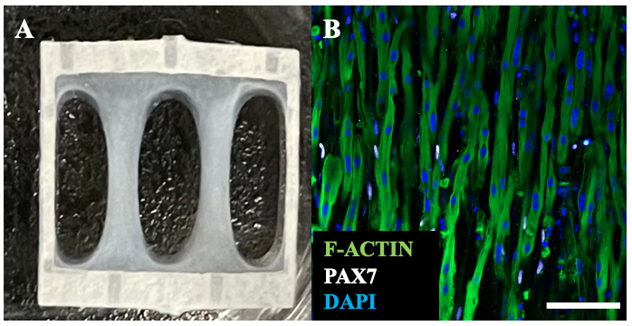

First, I wanted to begin by ensuring I would have the libraries I would need for data analysis, specifically tidyverse, tidybiology, dplyr, gglot2, ggsignif, plotrix, and fontawesome.

Next, I imported and glimpsed my data to make sure it looked alright.

```
## Rows: 26
## Columns: 10
## $ GF_Treatment       <chr> "CTL", "CTL", "CTL", "CTL", "CTL", "CTL", "CTL", "C…
## $ Donor              <chr> "s124", "s124", "s124", "s134", "s134", "s134", "s1…
## $ Bundle             <dbl> 1, 2, 3, 4, 5, 6, 7, 8, 9, 10, 11, 12, 13, 14, 15, …
## $ Paxsevpos          <dbl> 109, 111, 151, 52, 64, 57, 12, 17, 22, 149, 163, 18…
## $ Edupos             <dbl> 0, 0, 1, 0, 0, 0, 0, 0, 0, 8, 8, 3, 29, 14, 0, 3, 0…
## $ Cell_Count         <dbl> 278, 299, 330, 265, 316, 308, 236, 246, 218, 347, 2…
## $ EduposPaxsevpos    <dbl> 0, 0, 0, 0, 0, 0, 0, 0, 0, 1, 3, 1, 16, 3, 0, 0, 0,…
## $ Paxsevper          <dbl> 39.208633, 37.123746, 45.757576, 19.622642, 20.2531…
## $ EduposPaxsevposper <dbl> 0.0000000, 0.0000000, 0.0000000, 0.0000000, 0.00000…
## $ Eduposper          <dbl> 0.0000000, 0.0000000, 0.3030303, 0.0000000, 0.00000…
```

It was a relief that my data appeared to import ok and looked usable.

### Visualizing My Raw Data

I wanted to visualize the three most important measures (Pax7+%, edu+%, and Pax7+/edu+%) individually, starting with the percentage of *Pax7* positive cells in myobundles. I thought a boxplot made the most sense, and placed my data points on overlaying the boxplot because there are not too many point. This allowed me to more clearly see the data variation.

#### *Pax7* Plot for Satellite Cell Population Quantification

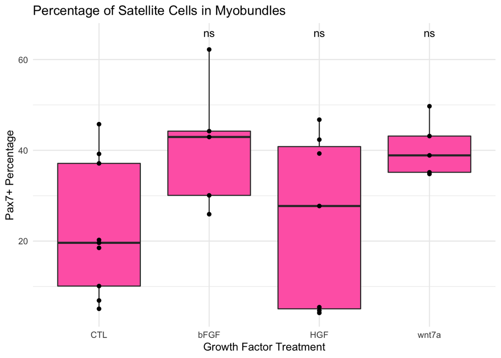

From this first graph, I see a higher percentage of *Pax7* positive cells when myobundles are treated with bFGF and wnt7a but no treatment group is statistically significant. I really don’t see too much of a difference between the control myobundles and HGF.  
I then wanted to visualize the percentage of edu positive cells after growth factor treatment.

#### Edu Plot for Proliferation Assessment

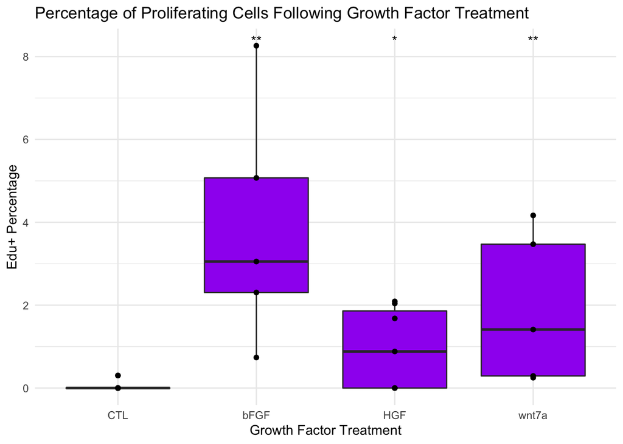

From the second graph, I see a higher percentage of edu positive cells when myobundles are treated with bFGF, HGF, and wnt7a and all are statistically significant (bFGF p < 0.01 & HGF p < 0.05 & wnt7a p < 0.01). However, if you look at the y-axis scale, the percentage of any group is not greater than 9%.  
Finally, I wanted to look at the percentage of cells which were edu and *Pax7* positive.

#### *Pax7* Plus EDU Plot for Proliferating Satelitte Cell Assessment

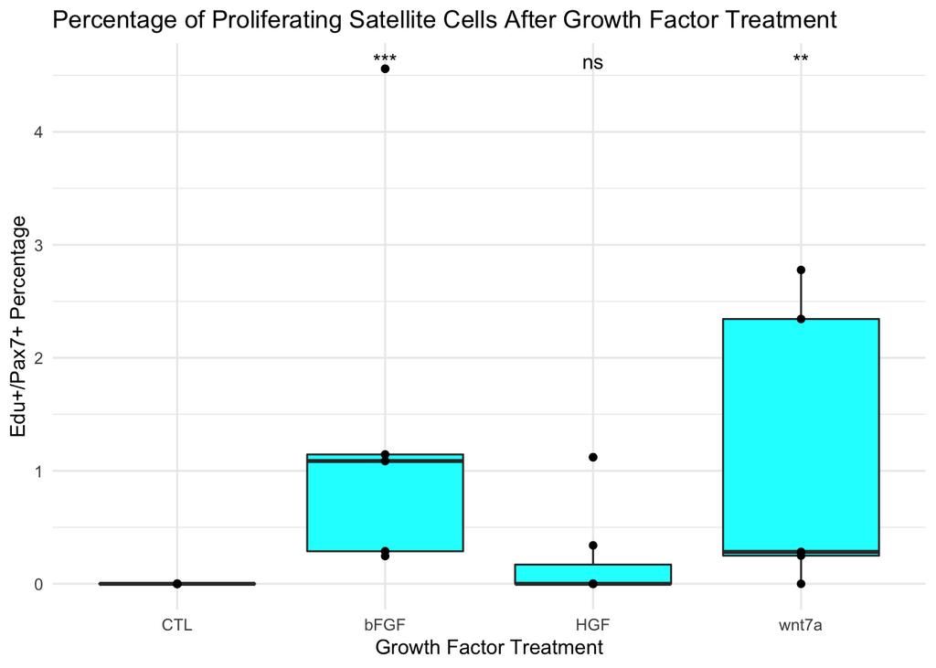

When looking at the third graph of my measureables, I see a higher percentage of *Pax7* positive and edu positive cells when myobundles are treated with bFGF, HGF, and wnt7a but only bFGF (p < 0.001) and wnt7a (p < 0.01) are statistically significant. Again, the y-axis is low in value, so the amount of proliferating satellite cells is not very high.

### Final Plot

For the final visualization of my data, I wanted to directly compare the different percentages of my groups on a single **bar graph**!

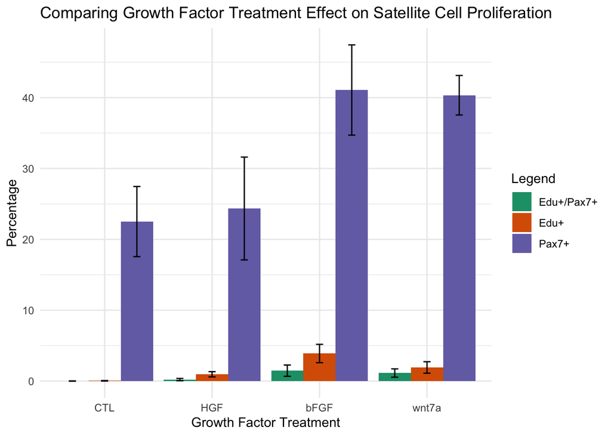

### Conclusions

From my final graph, I can conclude bFGF and wnt7a had the most significant impact on the population of satellite cells within myobundles.

### Prioritized Follow-Up Studies

#### Experimental Next Steps

Next steps involve functional testing of the growth-factor treated myobundles to determine if the increased satellite cell population increases myobundle force generation.

#### Troubleshooting

I would expect the edu+/*Pax7*+ population within each growth factor treatment group to make up the difference between the *Pax7*+ populations of the treatment group and control. I think I am not seeing that difference because images were taken from the middle of the myobundle and edu could not diffuse as deep as the growth factors. Follow-up studies could explore this further by taking z-stack images of myobundles to track edu diffusion into the myobundles.

### Acknowledgments

Thank you so much to the patient instructor **Matthew Hirschey** and the also very patient TAs **Akshay Bareja**, **Junqi Lu**, and **Devang Thakkar**.  
Thank you to the Bursac lab for helping fascilitate this research!

[figure not shown]

Funding Source: I am currently funded by T32GM008555